# Lesson 2

Lukasz Piszczek, Kaja Moczulska

2025-10-10

# Load Data

Purpose: Load Alzheimer’s gene expression data and metadata; clean and reshape for analysis.

Here we will work on Alzheimers data: Microarray analysis of postmortem human brains with presence or absence of Alzheimer’s disease

**Format** A tibble with gene expression, brain regions, patient data. **Source** Data taken from https://europepmc.org/article/MED/23595620 https://academic.oup.com/cercor/article/24/9/2476/319502 https://www.ebi.ac.uk/gxa/experiments/E-GEOD-36980/Downloads

```r
# Select genes of interest for analysis (defined by biological relevance or prior studies).
genes <- c(
  "MET", "PCSK1", "RGS4", "HS3ST2", "NPTX2", "NEUROD6",
  "RAB27B", "IL12RB2", "FAM19A1", "HCN1", "GABRA1", "KIAA1045", "PRKCB", "HPCA", "PTPN3", "SERPINF1",
  "WIPF3", "GFRA2", "HS6ST3", "PARM1", "NUAK1", "NRN1", "VEGFA", "ENC1", "RAB15", "SATB1", "PHACTR1",
  "ANO3", "HOPX", "ELAVL4", "CPLX1", "C14orf83", "EHD3", "KIAA0746", "LINGO1", "KCNK9", "ACOT7", "MSC",
  "PDE2A", "HCN2", "FABP3", "SLC6A7", "RGS7", "WBSCR17", "ATP2B2", "NEFH", "RIT2", "EGR3", "GNG3",
  "NPTXR", "ARHGDIG", "CCKBR", "ST8SIA5", "SLC6A17", "ATRNL1", "LDB2", "SYT13", "SMYD2",
  "MAN1A1", "GABRG2", "STMN2", "L1CAM", "C12orf5", "HOMER1", "SYT7", "TRIM36", "EFNA3", "DLGAP1",
  "GABBR2", "FRMPD4", "RIMBP2", "INA", "AACS", "STRBP", "CHRNB2", "ATP2B3", "TTYH3", "RTN4RL1",
  "SYT5", "GABRA4", "DAGLA", "CDH22", "SEZ6L2", "SLC17A7", "NEFL", "OXR1", "ADAM11",
  "LIPH", "NAP1L2", "SYNGR3", "TOM1L1", "KCNJ6", "UQCRH", "STX1B", "GABRA5", "ACOT8", "ORAI2",
  "SNAP25", "WBSCR17", "PPP1R16B", "TOLLIP", "LARGE", "GLRB", "PTPRN", "SYT4", "DUSP6", "DOC2A",
  "SPTBN2", "NEDD4L", "POPDC3", "SYN1", "PREP", "MMP17",
  "QPCT", "CPT1C", "NDFIP2", "ARL15", "DPF1", "HPRT1", "ATP6V1G2", "SH3RF1", "KCNF1", "PTPN5",
  "MAPK9", "PFKP", "PTPRN2", "TLN2", "GDAP1L1", "ISLR2", "ADAP1", "C3orf14", "TSPAN5", "APBA2",
  "RNF165", "SLC7A14", "TOMM22", "FNDC5", "YWHAG", "KRT222",
  "SLC7A11", "GOLIM4",
  "HSD17B7P2", "LAMA4",
  "IFLTD1", "PCDHB4", "COL21A1", "CNGA3", "FAM36A",
  "EGF", "FAP", "FIBIN", "SNTB1", "TAS2R31",
  "CA5B", "NCRNA00173",
  "SSPN",
  "ANGPT1", "B3GAT2", "VCAN", "GJA1", "VCAM1",
  "ST6GALNAC2", "TXNIP", "ARRDC4", "WDR49", "AEBP1", "PIRT", "GALNTL2"
)
# Optionally: select a smaller subset for focused analysis.
test_genes <- c("MET", "PCSK1", "PTPN3", "SERPINF1", "VEGFA", "NEFH", "EGR3", "HOMER1", "INA", "DAGLA",
  "CDH22", "NEFL", "TOM1L1", "TOLLIP", "SH3RF1", "TOMM22", "AEBP1", "TXNIP", "VCAM1", "ANGPT1",
  "RGS4", "GABRA1", "GFRA2", "CPLX1", "KCNK9", "RGS7", "GABRG2", "STMN2", "L1CAM", "SYT7",
  "SYT5", "GABRA4", "KCNJ6", "STX1B", "GABRA5", "SNAP25", "PTPRN", "SYT4", "DUSP6", "PTPN5",
  "PTPRN2", "IL12RB2", "PRKCB", "WIPF3", "NRN1", "ENC1", "SATB1", "PHACTR1", "ELAVL4", "FABP3",
  "AACS", "SPTBN2", "YWHAG")

# Read normalized gene expression table. Drop unneeded columns; keep gene names.
df <- read_delim(file = "./Input_data/E-GEOD-36980-A-AFFY-141-normalized-expressions.tsv") %>%
  select(-`Gene ID`, -DesignElementAccession) %>%      # Remove Gene ID columns as not needed
  rename(Gene = `Gene Name`) %>%                       # Rename for clarity
  pivot_longer(cols = starts_with("GSM"),              # Reshape: aim is to have one row per patient
    names_to = "Assay", values_to = "Gene_expression") %>%
  pivot_wider(names_from = Gene, values_from = Gene_expression, values_fn = mean) %>%
  dplyr::select(Assay, any_of(genes))                  # Keep only selected genes
df_meta <- read_delim(file = "./Input_data/E-GEOD-36980-experiment-design.tsv") %>%
  dplyr::select(Assay, `Sample Characteristic[disease]`, `Sample Characteristic[sex]`, `Sample Characteristic[organism part]`) %>%
  rename(Class = `Sample Characteristic[disease]`, # Rename for readability
         sex = `Sample Characteristic[sex]`,
         Brain_Area = `Sample Characteristic[organism part]`) %>%
  mutate(Class = factor(Class), # Convert to categorical
         sex = factor(sex),
         Brain_Area = factor(Brain_Area))
# Merge gene expression and metadata on assay ID to create full analysis table.
df <- df %>% left_join(df_meta, ., by = "Assay") #%>% filter(Brain_Area == "hippocampus")
```

## Ivestigate the data structure

Lets investigate the data set

```r
# Show structure of the main data frame (column types, dimensions).
str(df)
```

```
## tibble [79 × 154] (S3: tbl_df/tbl/data.frame)
##  $ Assay     : chr [1:79] "GSM907792" "GSM907793" "GSM907794" "GSM907795" ...
##  $ Class     : Factor w/ 2 levels "Alzheimers disease",..: 1 1 1 1 1 1 1 1 1 1 ...
##  $ sex       : Factor w/ 2 levels "female","male": 2 1 1 2 1 1 1 1 1 2 ...
##  $ Brain_Area: Factor w/ 3 levels "frontal cortex",..: 1 1 1 1 1 1 1 1 1 1 ...
##  $ MET       : num [1:79] 8.29 7.3 8.34 7.8 7.48 ...
##  $ PCSK1     : num [1:79] 9.8 9.65 9.71 9.75 9.21 ...
##  $ RGS4      : num [1:79] 12.1 11.9 11.9 11.8 11.7 ...
##  $ HS3ST2    : num [1:79] 9.09 9.36 9.04 9.22 9.03 ...
##  $ NPTX2     : num [1:79] 8.95 9.11 8.65 9.03 8.43 ...
##  $ NEUROD6   : num [1:79] 8.38 8.41 8.3 8.23 7.64 ...
##  $ RAB27B    : num [1:79] 10.07 9.58 9.94 9.76 9.92 ...
##  $ IL12RB2   : num [1:79] 8.05 7.68 7.85 8.01 7.82 ...
##  $ HCN1      : num [1:79] 11.5 10.8 11.5 11.2 11.4 ...
##  $ GABRA1    : num [1:79] 11.9 11.4 11.9 11.7 11.7 ...
```

[output cut: 86 more lines]

And use the *dlookr* library to do summaries

```
## # A tibble: 6 × 6
##   variables  types     missing_count missing_percent unique_count unique_rate
##   <chr>      <chr>             <int>           <dbl>        <int>       <dbl>
## 1 Assay      character             0               0           79      1
## 2 Class      factor                0               0            2      0.0253
## 3 sex        factor                0               0            2      0.0253
## 4 Brain_Area factor                0               0            3      0.0380
## 5 MET        numeric               0               0           79      1
## 6 PCSK1      numeric               0               0           79      1
```

```
## # A tibble: 6 × 10
##   variables   min    Q1  mean median    Q3   max  zero minus outlier
##   <chr>     <dbl> <dbl> <dbl>  <dbl> <dbl> <dbl> <int> <int>   <int>
## 1 MET        6.03  7.90  8.33   8.29  8.89  9.66     0     0       2
## 2 PCSK1      6.30  8.87  9.32   9.43  9.89 10.9      0     0       3
## 3 RGS4       8.32 11.7  11.7   11.9  12.1  12.5      0     0       9
## 4 HS3ST2     7.94  8.79  8.99   8.98  9.15 10.8      0     0      12
## 5 NPTX2      8.35  8.81  9.34   9.19  9.85 11.1      0     0       0
## 6 NEUROD6    6.60  8.02  8.34   8.38  8.70  9.60     0     0       3
```

```
## # A tibble: 6 × 6
##   variables levels        N  freq ratio  rank
##   <chr>     <chr>     <int> <int> <dbl> <int>
## 1 Assay     GSM907792    79     1  1.27     1
## 2 Assay     GSM907793    79     1  1.27     1
## 3 Assay     GSM907794    79     1  1.27     1
## 4 Assay     GSM907795    79     1  1.27     1
## 5 Assay     GSM907796    79     1  1.27     1
## 6 Assay     GSM907797    79     1  1.27     1
```

# Select and Standardize the Data

Here we will select our variables, taking only numeric columns. As PCA works best on scaled data we will center and scale numeric columns: Explanation: We scale the numeric gene expression data for consistent distance measurement.

# Perform PCA

Run PCA What is it? PCA is a dimensionality reduction technique that transforms a large set of correlated variables into a smaller set of uncorrelated principal components. Each principal component captures the maximum possible variance from the data in decreasing order. Why use it? We use PCA to simplify complex gene expression data, highlight the main patterns, and make clusters or differences between healthy and Alzheimer’s patients easier to see and analyze.

```
## Importance of components:
##                           PC1    PC2     PC3     PC4     PC5     PC6    PC7
## Standard deviation     9.1829 3.4445 2.67174 2.33756 2.07085 1.84366 1.6523
## Proportion of Variance 0.5622 0.0791 0.04759 0.03643 0.02859 0.02266 0.0182
## Cumulative Proportion  0.5622 0.6413 0.68886 0.72529 0.75388 0.77654 0.7947
##                            PC8     PC9    PC10    PC11    PC12   PC13   PC14
## Standard deviation     1.58523 1.53867 1.45676 1.29448 1.23247 1.2001 1.1747
## Proportion of Variance 0.01675 0.01578 0.01415 0.01117 0.01013 0.0096 0.0092
## Cumulative Proportion  0.81149 0.82727 0.84142 0.85259 0.86272 0.8723 0.8815
##                           PC15    PC16    PC17   PC18    PC19   PC20    PC21
## Standard deviation     1.08973 1.04191 0.99742 0.9645 0.94773 0.9250 0.85192
## Proportion of Variance 0.00792 0.00724 0.00663 0.0062 0.00599 0.0057 0.00484
## Cumulative Proportion  0.88944 0.89667 0.90331 0.9095 0.91550 0.9212 0.92604
##                          PC22    PC23    PC24    PC25    PC26    PC27    PC28
## Standard deviation     0.8488 0.82585 0.80473 0.75060 0.74985 0.71846 0.68915
## Proportion of Variance 0.0048 0.00455 0.00432 0.00376 0.00375 0.00344 0.00317
## Cumulative Proportion  0.9308 0.93539 0.93971 0.94346 0.94721 0.95065 0.95382
##                           PC29    PC30    PC31    PC32    PC33    PC34   PC35
## Standard deviation     0.68423 0.65563 0.62587 0.59855 0.58374 0.56821 0.5478
## Proportion of Variance 0.00312 0.00287 0.00261 0.00239 0.00227 0.00215 0.0020
## Cumulative Proportion  0.95694 0.95980 0.96242 0.96480 0.96708 0.96923 0.9712
##                           PC36    PC37    PC38    PC39    PC40    PC41    PC42
## Standard deviation     0.52908 0.51217 0.49769 0.48818 0.48097 0.44896 0.43618
## Proportion of Variance 0.00187 0.00175 0.00165 0.00159 0.00154 0.00134 0.00127
## Cumulative Proportion  0.97310 0.97484 0.97650 0.97808 0.97963 0.98097 0.98224
##                           PC43    PC44    PC45    PC46    PC47    PC48    PC49
## Standard deviation     0.42611 0.41776 0.40255 0.38412 0.37415 0.36563 0.35633
## Proportion of Variance 0.00121 0.00116 0.00108 0.00098 0.00093 0.00089 0.00085
## Cumulative Proportion  0.98345 0.98461 0.98569 0.98668 0.98761 0.98850 0.98935
##                           PC50    PC51    PC52    PC53    PC54    PC55    PC56
## Standard deviation     0.33415 0.32916 0.31769 0.31153 0.31047 0.29856 0.29058
## Proportion of Variance 0.00074 0.00072 0.00067 0.00065 0.00064 0.00059 0.00056
## Cumulative Proportion  0.99009 0.99081 0.99149 0.99213 0.99278 0.99337 0.99393
##                           PC57    PC58    PC59    PC60    PC61    PC62    PC63
## Standard deviation     0.28012 0.27690 0.26508 0.26091 0.25051 0.23663 0.23643
## Proportion of Variance 0.00052 0.00051 0.00047 0.00045 0.00042 0.00037 0.00037
## Cumulative Proportion  0.99446 0.99497 0.99544 0.99589 0.99631 0.99668 0.99705
##                           PC64    PC65    PC66    PC67    PC68    PC69    PC70
## Standard deviation     0.22640 0.21902 0.20290 0.20187 0.19324 0.18293 0.18149
## Proportion of Variance 0.00034 0.00032 0.00027 0.00027 0.00025 0.00022 0.00022
## Cumulative Proportion  0.99740 0.99772 0.99799 0.99826 0.99851 0.99873 0.99895
##                           PC71    PC72    PC73    PC74    PC75   PC76    PC77
## Standard deviation     0.16813 0.16721 0.15496 0.13799 0.13303 0.1222 0.11829
## Proportion of Variance 0.00019 0.00019 0.00016 0.00013 0.00012 0.0001 0.00009
## Cumulative Proportion  0.99914 0.99933 0.99949 0.99962 0.99973 0.9998 0.99993
##                           PC78      PC79
## Standard deviation     0.10482 1.201e-14
## Proportion of Variance 0.00007 0.000e+00
## Cumulative Proportion  1.00000 1.000e+00
```

## Scree Plot: Proportion of Variance Explained

The scree plot helps visualize the variance explained by each component.

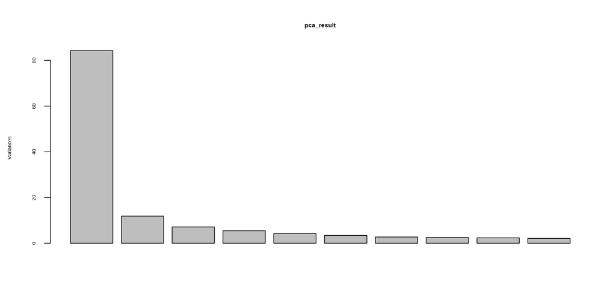

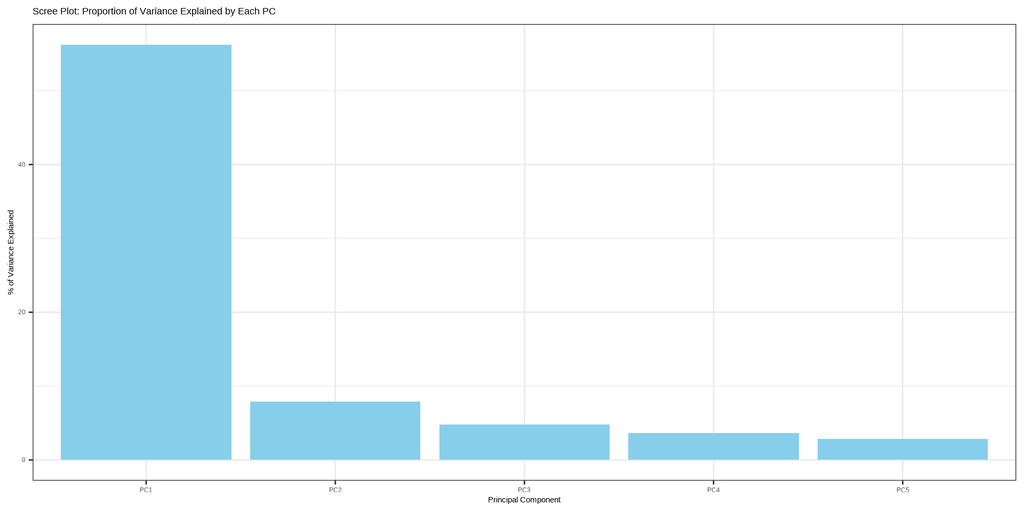

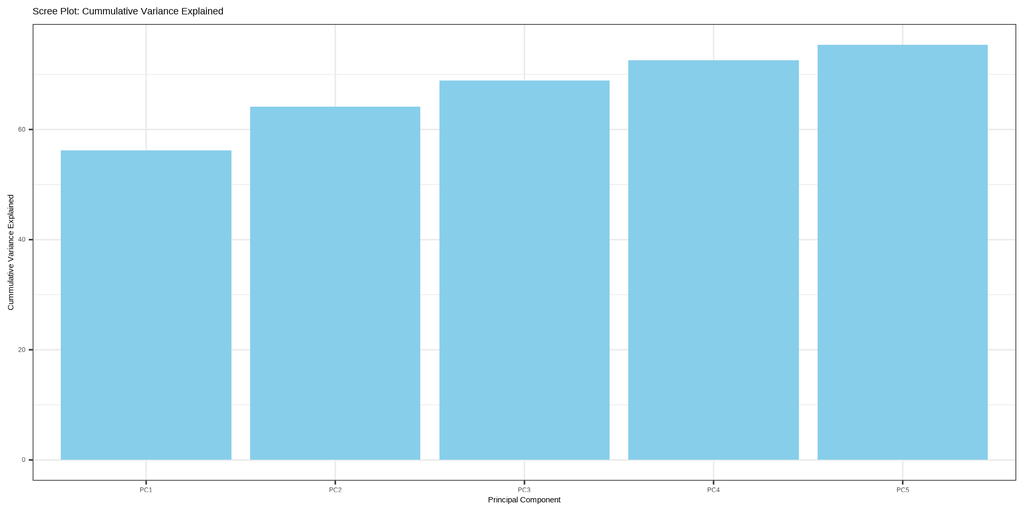

## Plot rotations

Next, we plot the rotation matrix. The rotation matrix is stored as pca_result$rotation, but here we’ll extract it using the tidy() function from broom. When applied to prcomp objects, the tidy() function takes an additional argument matrix, which we set to matrix = “rotation” to extract the rotation matrix. Purpose: See which genes contribute most to each principal component.

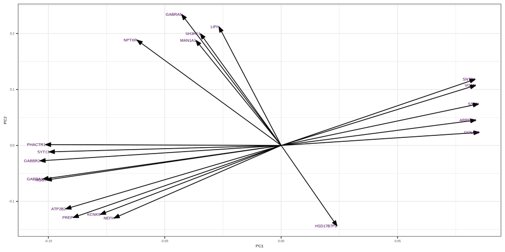

Purpose: Visualize how patients cluster by principal components. Color points by diagnosis.

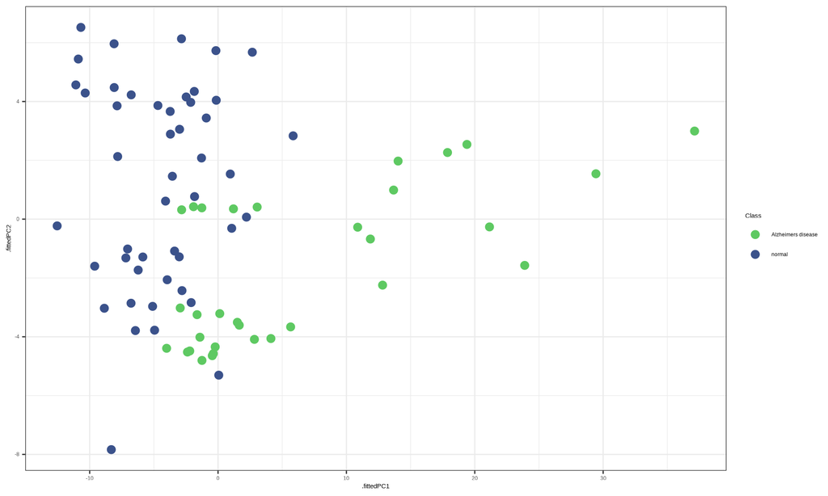

# UMAP

What is it? UMAP is a nonlinear dimensionality reduction method that projects high-dimensional data into a lower-dimensional space (usually 2D), focusing on preserving both global structure and local relationships. Why use it? UMAP enables clearer visualization of gene expression patterns, helping us spot distinct clusters of patient groups that may not be obvious with linear methods like PCA. Purpose: Alternative dimensionality reduction (good for nonlinear structures).

## Plot UMAP

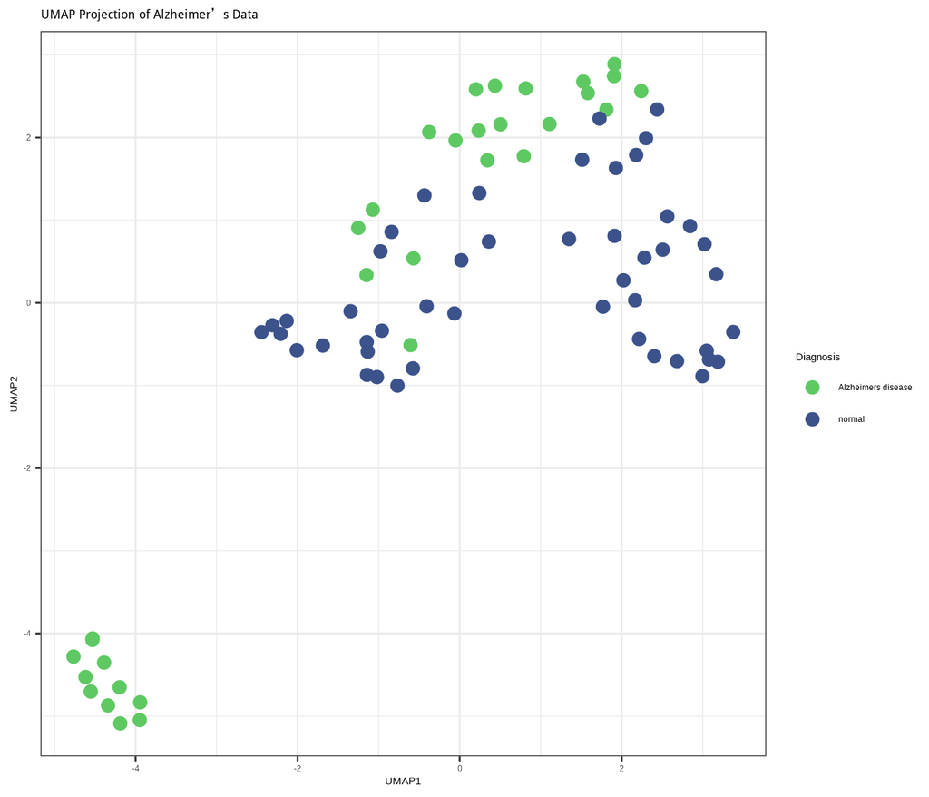

## UMAP on PCA Purpose: Apply UMAP after reducing to 4 principal components. May improve clustering.

### Plot UMAP on PCA

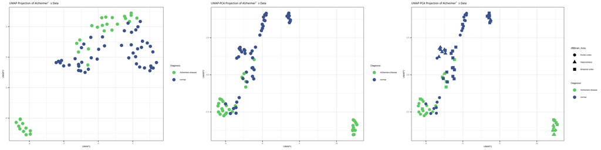

# k-means Clustering (Unsupervised)

What is it? k-means is an unsupervised learning algorithm that divides data into k clusters based on similarity, by minimizing the distance between each point and the center of its assigned cluster. Why use it? In gene expression analysis, k-means helps automatically identify groups (clusters) of patients that share similar gene profiles, potentially separating healthy individuals from those with Alzheimer’s disease without using diagnosis labels. Purpose: Group patients based on gene expression, without using diagnosis labels.

### K-means K evaluation

We run k-means clustering 10 times from k = 1 to k = 10. WSS measures compactness of clusters; the “elbow” point in the scree plot suggests optimal cluster number.

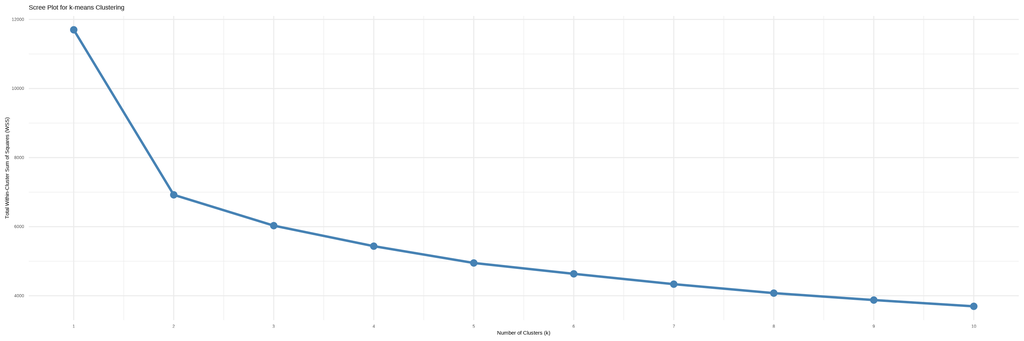

## Run k-means

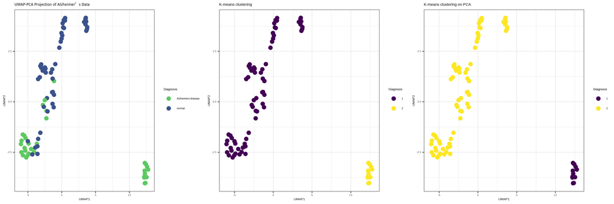

# K-NN What is it? k-NN is a supervised classification technique that predicts the category of a sample by looking at the ‘k’ closest samples in the data and assigning the most common class among neighbors. Why use it? k-NN allows us to test whether patterns in gene expression can reliably distinguish between healthy and Alzheimer’s patients, using known labels on part of the data to predict the rest. Purpose: Predict diagnosis using gene expression profiles (supervised learning).

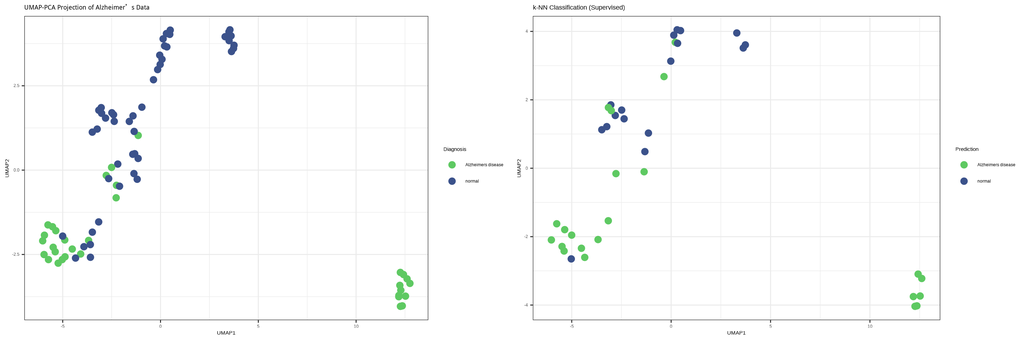

##practical assesment

As an assessment kindly email following information: 1. How many PCA’s is needed to reach over 80% variance explained in our data set? 2. How does the n_neighbors parameter in UMAP affect the plots? 3. what is the main difference between k-means and k-nn and in which case could you use them? 4. what is a sensible k parameter in k-nn to choose?

to: kaja.moczulska@meduniwien.ac.at or lukasz.piszczek@meduniwien.ac.at